# UEFA Champions Cup Winner Predictor

Noe Lomeli, Michael Sanchez, Israel Andrade

5/12/2018

## Introduction:

This project tries to predicted how well a European team is set to perform in the Champions league tournament. The data that was collected consisted of 11 European Countries, +10,000 players, +25,000 matches from seasons 2008 to 2016.

```r
library(DBI)
library(e1071)
library(rpart)
library(rpart.plot)
library(maptree)
# the following utility files can be found attached to the assignment
source("https://raw.githubusercontent.com/grbruns/cst383/master/lin-regr-util.R")
source("https://raw.githubusercontent.com/grbruns/cst383/master/class-util.R")
#db <- dbConnect(RSQLite::SQLite(),"database.sqlite")
db <- dbConnect(RSQLite::SQLite(),"/Users/israel_andrade/Documents/spring2018/data_science/soccer_project/database.sqlite")

Country <- dbGetQuery(db,"Select * from Country")
Match <- dbGetQuery(db,"Select * from Match")
League <- dbGetQuery(db,"Select * from League")
Team <- dbGetQuery(db,"Select * from Team")
Team_Attributes <- dbGetQuery(db, "Select * from Team_Attributes")

Match[12:78] = NULL
Match[19:48] = NULL

#  convert columns 12 -18 to numeric
Match[, 12:18] <- sapply(Match[, 12:18], as.numeric)

#replace all NAs with 0s
Match = replace(Match, is.na(Match), 0)
Team = replace(Team, is.na(Team), 0)
summary(Match)
```

```
##        id          country_id      league_id        season
##  Min.   :    1   Min.   :    1   Min.   :    1   Length:25979
##  1st Qu.: 6496   1st Qu.: 4769   1st Qu.: 4769   Class :character
##  Median :12990   Median :10257   Median :10257   Mode  :character
##  Mean   :12990   Mean   :11739   Mean   :11739
##  3rd Qu.:19484   3rd Qu.:17642   3rd Qu.:17642
##  Max.   :25979   Max.   :24558   Max.   :24558
##      stage           date            match_api_id     home_team_api_id
##  Min.   : 1.00   Length:25979       Min.   : 483129   Min.   :  1601
##  1st Qu.: 9.00   Class :character   1st Qu.: 768436   1st Qu.:  8475
##  Median :18.00   Mode  :character   Median :1147511   Median :  8697
##  Mean   :18.24                      Mean   :1195429   Mean   :  9984
##  3rd Qu.:27.00                      3rd Qu.:1709852   3rd Qu.:  9925
##  Max.   :38.00                      Max.   :2216672   Max.   :274581
##  away_team_api_id home_team_goal   away_team_goal      shoton     shotoff
##  Min.   :  1601   Min.   : 0.000   Min.   :0.000   Min.   :0   Min.   :0
##  1st Qu.:  8475   1st Qu.: 1.000   1st Qu.:0.000   1st Qu.:0   1st Qu.:0
##  Median :  8697   Median : 1.000   Median :1.000   Median :0   Median :0
##  Mean   :  9984   Mean   : 1.545   Mean   :1.161   Mean   :0   Mean   :0
##  3rd Qu.:  9925   3rd Qu.: 2.000   3rd Qu.:2.000   3rd Qu.:0   3rd Qu.:0
##  Max.   :274581   Max.   :10.000   Max.   :9.000   Max.   :0   Max.   :0
##    foulcommit      card       cross       corner    possession
##  Min.   :0    Min.   :0   Min.   :0   Min.   :0   Min.   :0
##  1st Qu.:0    1st Qu.:0   1st Qu.:0   1st Qu.:0   1st Qu.:0
##  Median :0    Median :0   Median :0   Median :0   Median :0
##  Mean   :0    Mean   :0   Mean   :0   Mean   :0   Mean   :0
##  3rd Qu.:0    3rd Qu.:0   3rd Qu.:0   3rd Qu.:0   3rd Qu.:0
##  Max.   :0    Max.   :0   Max.   :0   Max.   :0   Max.   :0
```

```r
str(Match)
```

```
## 'data.frame':    25979 obs. of  18 variables:
##  $ id              : int  1 2 3 4 5 6 7 8 9 10 ...
##  $ country_id      : int  1 1 1 1 1 1 1 1 1 1 ...
##  $ league_id       : int  1 1 1 1 1 1 1 1 1 1 ...
##  $ season          : chr  "2008/2009" "2008/2009" "2008/2009" "2008/2009" ...
##  $ stage           : int  1 1 1 1 1 1 1 1 1 10 ...
##  $ date            : chr  "2008-08-17 00:00:00" "2008-08-16 00:00:00" "2008-08-16 00:00:00" "2008-08-17 00:00:00" ...
##  $ match_api_id    : int  492473 492474 492475 492476 492477 492478 492479 492480 492481 492564 ...
##  $ home_team_api_id: int  9987 10000 9984 9991 7947 8203 9999 4049 10001 8342 ...
##  $ away_team_api_id: int  9993 9994 8635 9998 9985 8342 8571 9996 9986 8571 ...
##  $ home_team_goal  : int  1 0 0 5 1 1 2 1 1 4 ...
##  $ away_team_goal  : int  1 0 3 0 3 1 2 2 0 1 ...
##  $ shoton          : num  0 0 0 0 0 0 0 0 0 0 ...
##  $ shotoff         : num  0 0 0 0 0 0 0 0 0 0 ...
##  $ foulcommit      : num  0 0 0 0 0 0 0 0 0 0 ...
##  $ card            : num  0 0 0 0 0 0 0 0 0 0 ...
##  $ cross           : num  0 0 0 0 0 0 0 0 0 0 ...
##  $ corner          : num  0 0 0 0 0 0 0 0 0 0 ...
##  $ possession      : num  0 0 0 0 0 0 0 0 0 0 ...
```

```r
#Count the number of matches the particular team played at home
home_match = as.data.frame(table(Match$home_team_api_id))

#Count the number of matches the particular team played at home
away_match = as.data.frame(table(Match$away_team_api_id))

names(home_match)[names(home_match)=="Freq"] <- "home_matches_number"
names(away_match)[names(away_match)=="Freq"] <- "away_matches_number"

new_match_data <- as.data.frame(cbind(home_match,away_match))

new_match_data$total_matches =  new_match_data$home_matches_number + new_match_data$away_matches_number
new_match_data$wins = 0
new_match_data$win_percentage = 0
new_match_data$country = ""
new_match_data$team_name = ""

# rename duplicate column
names(new_match_data)[3]<-"away_team_api_id"
names(new_match_data)[names(new_match_data)=="Var1"] <- "home_team_api_id"
head(new_match_data)
```

```
##   home_team_api_id home_matches_number away_team_api_id
## 1             1601                 120             1601
## 2             1773                  45             1773
## 3             1957                 120             1957
## 4             2033                  75             2033
## 5             2182                 120             2182
## 6             2183                  75             2183
##   away_matches_number total_matches wins win_percentage country team_name
## 1                 120           240    0              0
## 2                  45            90    0              0
## 3                 120           240    0              0
## 4                  75           150    0              0
## 5                 120           240    0              0
## 6                  75           150    0              0
```

```r
for(row1 in rownames(new_match_data))
{
  home_indexes = which(Match$home_team_api_id == new_match_data$home_team_api_id[as.numeric(row1)])
  new_match_data$country[as.numeric(row1)] <- Country$name[Country$id==Match$country_id[as.numeric(home_indexes[1])]]
  new_match_data$team_name[as.numeric(row1)] <- Team$team_long_name[Team$team_api_id==new_match_data$home_team_api_id[as.numeric(row1)]]
}

#Iterate over all the teams ids
for(id in rownames(new_match_data))
{
  #win_count stores the number of wins if the current team has scored more goals than the opponent team.
  win_count = 0
  #Find all the records in main "Match" table which match the current team id
  home_indexes = which(Match$home_team_api_id == new_match_data$home_team_api_id[as.numeric(id)])
  away_indexes = which(Match$away_team_api_id == new_match_data$away_team_api_id[as.numeric(id)])

  for(i in home_indexes)
  {
    if(Match$home_team_goal[i]>Match$away_team_goal[i])
    {
      win_count = win_count +1
    }
  }
  for(i in away_indexes)
  {
    if(Match$away_team_goal[i]>Match$home_team_goal[i])
    {
      win_count = win_count + 1
    }
  }

  new_match_data$wins[as.numeric(id)] <- win_count
  new_match_data$win_percentage[as.numeric(id)] <- as.double(win_count/new_match_data$total_matches[as.numeric(id)]*100)
}
```

## Data exploration and visualization:

From the inital observation of the four main data frames such as Match, League, Team, Team_Attributes we observed how they all correlated with each other. Match had the majority of information with over +25,000 entries. Values in Match include home and away team id, home goals, away goals, and league id. Team attribues had further information about the team such as team speed, passing rating, and defense aggression. In addition, Team_Attributes had each team assinged a class for each category in speed, passing, and defense. Values in defense range from pressing to containing and passing from organized to free-form.

## Total wins for home teams vs losses

### Description:

Based on all the data collected from each European Soccer League a barplot was constructed to graph the total wins of home and away teams. This was done to view if home teams are more likely to win a game versus playing an away team

### Result:

Home teams had an overall advatange when playing in their stadium versus team who were playing away. Home teams had the most wins compared to away teams

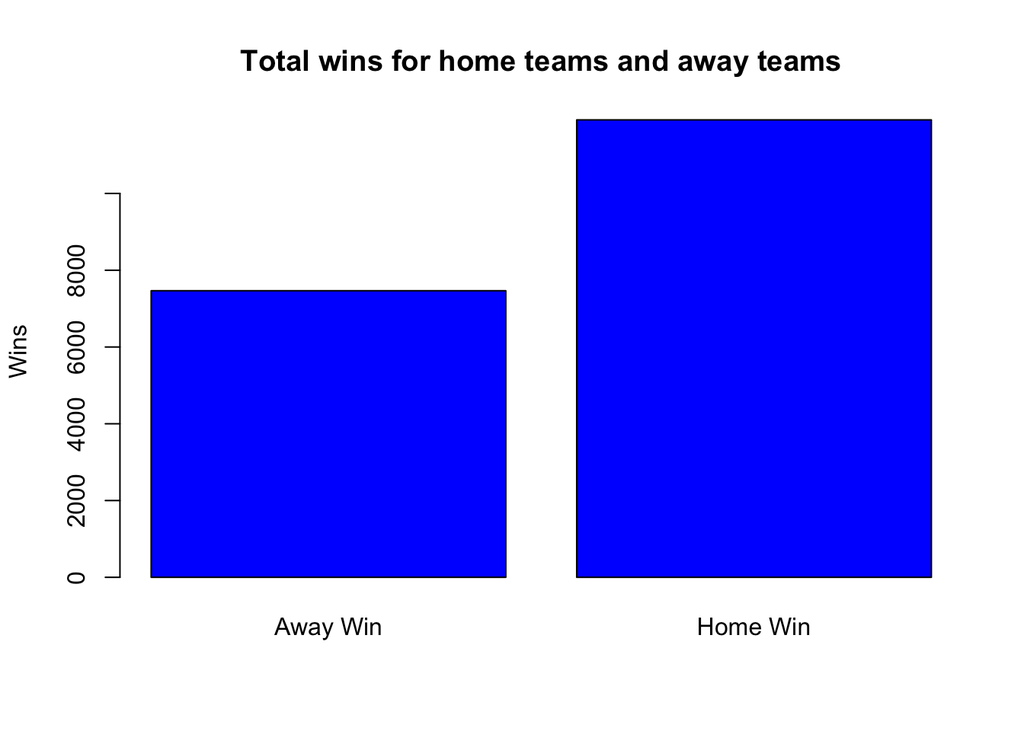

```r
noDraws = Match[Match$home_team_goal != Match$away_team_goal,]
typeOfWins = noDraws$home_team_goal > noDraws$away_team_goal
HomeWinsAndLosses = table(typeOfWins)
names(HomeWinsAndLosses) = c("Away Win", "Home Win")
barplot(HomeWinsAndLosses,ylab = "Wins", col = "blue", main = "Total wins for home teams and away teams")
```

## Home and Away Wins

### Result:

Home teams seems to have more wins than those of a team playing as visitors

```r
Team_Attributes = na.omit(Team_Attributes)

noDraws$homeWin = noDraws$home_team_goal > noDraws$away_team_goal
noDraws$output = factor(noDraws$homeWin, labels=c("Away Win", "Home Win"))

teamIds = unique(Team_Attributes$team_api_id)
temp = Team_Attributes[!duplicated(Team_Attributes$team_api_id),]
teamIds = temp$team_api_id

noDraws$awayDefenseAggression = 0
noDraws$homeDefenseAggression = 0
noDraws$awayBuildUpPlaySpeedClass = ""
noDraws$homeBuildUpPlaySpeedClass = ""
for(i in teamIds)
{
  if(!is.na(noDraws$away_team_api_id == i))
  {
    #print(i)
    key = i
    #print(temp[temp$team_api_id == key,]$defenceAggression)
    noDraws[noDraws$away_team_api_id == key,]$awayDefenseAggression = temp[temp$team_api_id == as.numeric(key),]$defenceAggression
    noDraws[noDraws$away_team_api_id == key,]$awayBuildUpPlaySpeedClass = temp[temp$team_api_id == as.numeric(key),]$buildUpPlaySpeedClass
  }
  if(!is.na(noDraws$home_team_api_id == i))
  {
    #print(i)
    key = i
    #print(temp[temp$team_api_id == key,]$defenceAggression)
    noDraws[noDraws$home_team_api_id == key,]$homeDefenseAggression = temp[temp$team_api_id == as.numeric(key),]$defenceAggression
    noDraws[noDraws$home_team_api_id == key,]$homeBuildUpPlaySpeedClass = temp[temp$team_api_id == as.numeric(key),]$buildUpPlaySpeedClass
  }
}
```

## Splitting data into training and test sets

```r
noDraws = na.omit(noDraws)
tr_rows = sample(nrow(noDraws), nrow(noDraws)*.8)
tr_dat = noDraws[tr_rows,]
te_dat = noDraws[-tr_rows,]
```

## Predict model based on home team winning

### Description

A Predict model based on whether a home team will win on preditors such as home defense aggression and away defense aggression

### Results

```r
actual = te_dat$output
fit = naiveBayes(output ~ homeDefenseAggression+awayDefenseAggression, data = tr_dat)
predicted = predict(fit, newdata=te_dat, type="class")
confusion_matrix = table(predicted, actual)
confusion_matrix
```

```
##           actual
## predicted  Away Win Home Win
##   Away Win      132       79
##   Home Win     1419     2247
```

```r
accuracy = mean(predicted == actual)
accuracy
```

```
## [1] 0.6136188
```

## Tree Graph

### Description:

A tree graph for illustrating how home defense, away defense, and speed class affect the final result of a match

### Result:

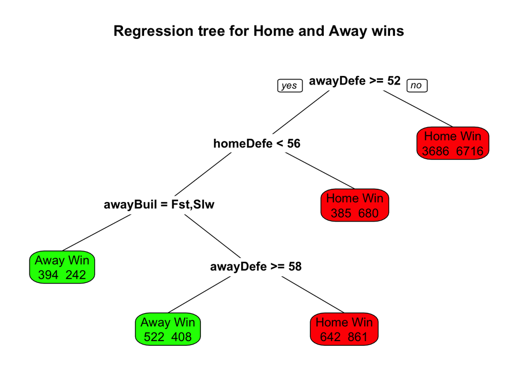

```r
# training and test sets
set.seed(132)
split = split_data(noDraws)
tr_dat = split[[1]]
te_dat = split[[2]]

fit  = rpart(output ~  homeDefenseAggression + awayDefenseAggression + homeBuildUpPlaySpeedClass + awayBuildUpPlaySpeedClass, data=tr_dat, method = "class")
prp(fit, extra=1, main="Regression tree for Home and Away wins",
    box.col=c("green", "red")[fit$frame$yval])
```

## Top ten winning percentages of European teams

### Description:

Based of the data collected for each team the percentage of winning percentage for the top ten teams were ploted using a barplot. The data used was from all Europeans teams which include Spain, UK, Germany, etc.

### Results:

The results from the barplot illustrate that Barcelona, Madrid CF, SL Benfica, FC Porto, Celtic, Rangers, Munich, Ajax, PSV, Anderlecht were the teams with the best performance in all of Europe

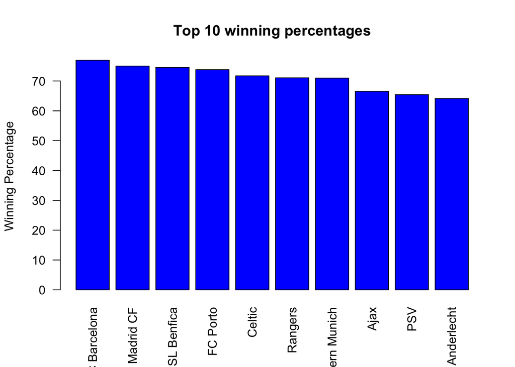

```r
#Drop Away_team_id column and change home_team_api_id columns name to team_id
drop_columns <- c("away_team_api_id")
new_match_data <- new_match_data[ , !names(new_match_data) %in% drop_columns]
names(new_match_data)[names(new_match_data)=="home_team_api_id"]<-"team_id"
#Sort the teams based on the winning percentage
sorted_data <- new_match_data[order(-new_match_data$win_percentage),]
barplot(sorted_data[0:10,]$win_percentage, names.arg=sorted_data[0:10,]$team_name, ylab = "Winning Percentage", las = 2, col = "blue", main = "Top 10 winning percentages")
```

## Top ten teams in the Premier League

### Description:

The top ten teams with the best winning percentages from the Premier League are displayed on a barplot to illustrate how likely a team from the Premier League team will win

### Results:

From the barplot teams like Manchester United and Chelsea have a more likely change to win compared to other teams like Liverpool or Everton

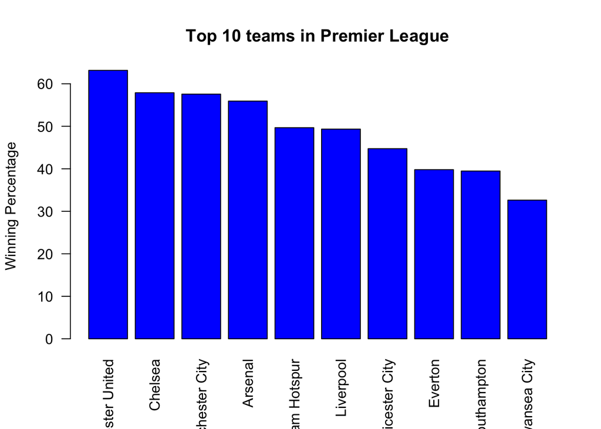

```r
#Find Best teams in England's England Premier League
english_team <- sorted_data[sorted_data$country=="England",]
england <- english_team[order(-english_team$win_percentage),][1:10,]
barplot(england$win_percentage, names.arg=england$team_name, ylab = "Winning Percentage", las = 2, col = "blue", main = "Top 10 teams in Premier League")
```

## Top ten teams in La Liga League

### Description:

The top ten teams with the best winning percentages from the La Liga are displayed on a barplot to illustrate how likely a team from the La Liga team will win

### Results:

From the barplot teams like Barcelona and Real Madrid have the best winning percentange compared to Celta de Vigo or Athletic Bilbao

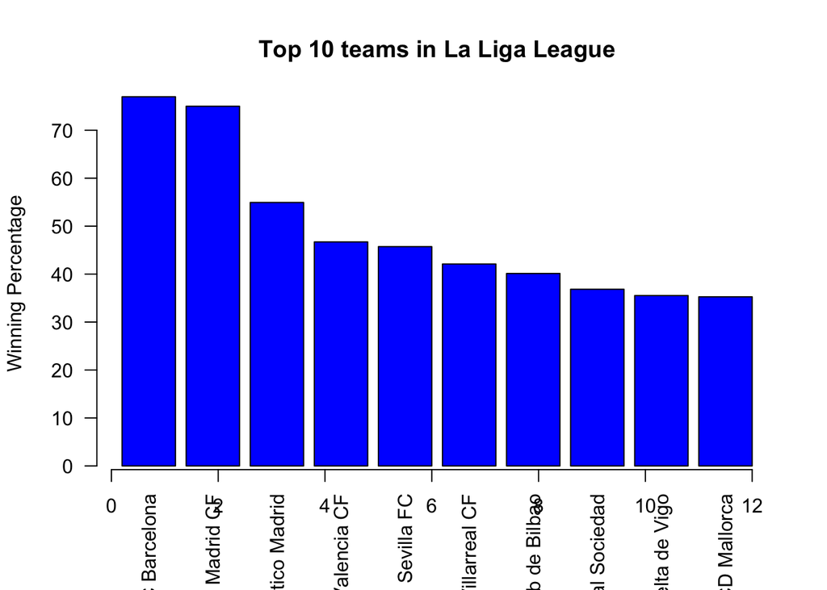

```r
#Find the top teams from spain league
spain_teams <- sorted_data[sorted_data$country=="Spain",]
spain <- spain_teams[order(-spain_teams$win_percentage),][1:10,]
barplot(spain$win_percentage, names.arg=spain$team_name, ylab = "Winning Percentage", las = 2, col = "blue", main = "Top 10 teams in La Liga League")
axis(1,cex.axis=1)
```

## Top ten teams in the Bundesliga League

### Description:

The top ten teams with the best winning percentage in the Bundesliga are illustrated in the barplot.

### Results:

Teams like Bayern and Dortmund have a better winning percentage than that of Hannover 96 or Hamburger SV

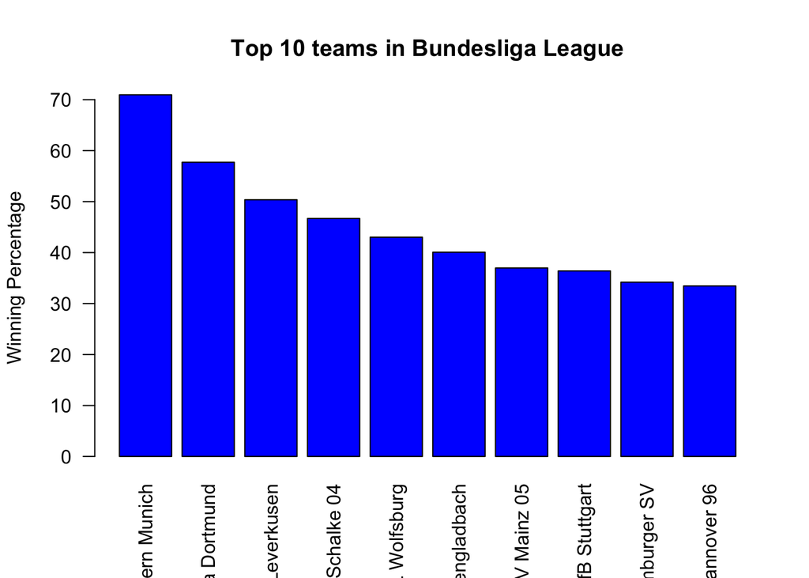

```r
#Find top teams in Germany's l Bundesliga League
german_team <- sorted_data[sorted_data$country=="Germany",]
germany <- german_team[order(-german_team$win_percentage),][1:10,]
barplot(germany$win_percentage, names.arg=germany$team_name, ylab = "Winning Percentage", las = 2, col = "blue", main = "Top 10 teams in Bundesliga League")
```

### Conclusion:

After exploring this european soccer data set, we realized that that team that plays at home gets more wins than those who play away. It seems as if you get an extra boost from having your fans supporting you at your home stadium. Those wins that came from the away teams were done by teams who always rank top 3 in the leagues we explored. For example, Bayern Munich as a top team from the German Bundesliga team has alot of away games won. This is because they have alot of better international players in their roster and home field advantage wont make a difference when they play vs a bottm half of the table team.